# Diversity in a Globalized World

Lecture 1: Who Paid for Globalization?

Bogdan G. Popescu

bgpopescu@tec.mx

Tecnológico de Monterrey

# The Course

## What this course is about

**A globalized world:** trade, money and migration tie distant places together.

**Diversity:** the same process lands very differently.

- **Places**: some gained from trade, others lost their factories
- **Politics**: some regions turned to populists, others did not
- **People**: some leave home, and send money to those who stay
- **Neighbourhoods**: some groups live side by side, others apart

An average hides all four. This week we look for them in the **data**.

## The week

| Day | Session | Question |
| --- | --- | --- |
| **Monday** | The China Shock and AI | Who paid for globalization? |
| Tuesday | Populism and Democratic Erosion | What did those losses do to politics? |
| Wednesday | Migration — *optional* | Why do people leave, and what follows them back? |
| Thursday | Segregation | Do different people ever actually meet? |
| Friday | Final Presentations | What did your team find? |

Wednesday 16 September is Independence Day, so that session is optional.

## A second course, about evidence

Every day, the same habit: **ask what the evidence actually shows.**

- **Monday**: a map reveals what a national average hides
- **Tuesday**: one wave of populism, four competing explanations
- **Wednesday**: one event, two economists, opposite conclusions
- **Thursday**: change the unit you measure, and the answer changes

By Friday you will have built one of these arguments yourself.

## Optional: the R you need

No background in economics, statistics or programming is required, and you can make your figures in Excel or Tableau. R is recommended. If you choose it, work through these decks from my [research workshop](https://bgpopescu.net/teaching/research_workshop/): they teach enough R to make maps and graphs, and nothing beyond that.

| Evening | Workshop decks | What they give your report |
| --- | --- | --- |
| Monday | Lecture 2: Essential Tools for Writing a Paper Lecture 3: Operations and Objects in R | R, RStudio and Quarto installed; the basics of R |
| Tuesday | Lecture 6: Working with Data in R Lecture 7: Dplyr and Basic Visualization | Loading the data, and your first graph |
| Wednesday | Lecture 13: Data Visualization in R 1 Lecture 14: Data Visualization in R 2 | Maps and colour scales |
| Thursday | Lecture 15: Data Visualization in R 3 | Facets: how the simple graph becomes the complex one |

Links are on each session page. The workshop’s statistics and regression decks are **not** part of this course.

## What you will be able to do

- **Describe** where globalization’s costs landed, and why averages mislead
- **Explain** economic and cultural accounts of the populist backlash
- **Explain** why people migrate, and what the evidence says about wages
- **Measure** how segregated a city is, and why the unit matters
- **Read a claim critically** — rival explanations, and what data cannot show
- **Produce** a short report with maps and graphs, in any tool

## Logistics

- **When**: Monday to Friday, 10:10–12:50 · **Where**: Aulas 11201
- **Instructor**: Bogdan Popescu · bgpopescu@tec.mx · office hours by appointment
- **Course site**: bgpopescu.net/teaching/diversity, one page per session
- **Reading**: one article per session, read together in class
- **Software**: Excel, Tableau or, ideally, R

## How you are graded

| Component | Weight |
| --- | --- |
| Team report | **40%** |
| Final presentation | **25%** |
| Reading quiz, Friday | **25%** |
| Contributions to class | **10%** |

**Contributions to class** — the average of:

- **Attendance**
- **Participation** in the in-class exercises
- **Progress** on your report

Your report mark is adjusted by your **team member evaluation**.

## The team report

**Teams of three.** One report, made with any tool, containing:

- **Two to three maps**
- **One simple graph** and **one more complex graph**
- **An interpretation** in your own words
- **A table** declaring your use of AI

Due **Friday at 10:10**, the start of the final session. Submit a PDF of the report and the file you made the figures in, on Canvas.

## Where the report marks are

|  | Points | Full marks means |
| --- | --- | --- |
| The question | 6 | one specific question, answerable with your data |
| The figures | 10 | titled, labelled, sourced, readable |
| **The interpretation** | **12** | you say what each figure shows, in your own words |
| **What you cannot say** | **8** | who is counted, which unit, one rival explanation |
| AI and working file | 4 | declaration complete, file opens and runs |

**Half the marks are the two bold rows.** Good figures with nothing said about them do not pass.

## Worked examples

Three finished reports built from this course’s data, made in R. Copy the structure in any tool.

- **The China Shock** — three maps and two graphs; the cleanest template
- **Whose jobs?** — the same data, a question the authors did not ask
- **Ask or delegate?** — global AI use, and who the data describes

You may take the **structure**. The **question**, the **choice of variables** and the **interpretation** have to be yours.

## The final presentation

**Friday. Ten minutes per team, plus questions.** Follow your report:

1. **The question** — one sentence
2. **The maps** — where the dark areas are, and what that means
3. **The graph** — the relationship you found
4. **What you cannot say** — the limitation that most threatens your conclusion
5. **One thing that surprised you**

Show your figures and talk about them. Do not read from the slide.

## Where the presentation marks are

|  | Points | Full marks means |
| --- | --- | --- |
| The question | 4 | one sentence, at the start |
| The figures, explained | 7 | you talk the room through a figure |
| What you cannot say | 5 | the limitation that threatens **your** conclusion |
| **Answering questions** | **7** | whoever made a choice can explain it |
| Time and teamwork | 2 | ten minutes, everyone speaks |

The biggest single row is **answering questions** — including where AI helped, and how you checked it.

## Use of AI

You **may** use AI, such as ChatGPT. You **must** declare it.

Every report ends with a short table: what you used it for, what you asked, and how you checked the answer.

- **Never submit work you cannot explain** — you will be asked
- **Use AI for the mechanical parts, not the judgement**

Fixing an error message is a good use. Deciding your question, or what your map means, is not.

## So what?

- The report is **40% of your grade**, due **Friday at 10:10**
- Today’s graphs and maps use **the data you will receive**

So watch *how* each argument is built, not only what it concludes. It is the model for your report.

# Today: Who Paid for Globalization?

## Two numbers

- Trade with China made almost everything in this room cheaper
- It also destroyed manufacturing jobs in particular towns

Both are true. Only one of them shows up in a national average.

Today: how you find the second one, and whether AI is doing the same thing again.

## Today’s objectives

- Describe where the China shock landed and how concentrated it was
- Explain what happened to workers in the places it hit
- Trace how the same shock reached **Mexico**, through the US market
- Compare a shock that follows **local industry** with one that does not
- Say what each dataset can and cannot show

# I. A Shock That Hit Places

## What happened

- China joined the World Trade Organization in **2001**
- Its manufactured exports rose faster than any country’s in history
- American factories competed with them, and many lost

That is the story everyone knows. The interesting question is *where* it landed, because it did not land evenly.

## The scale of it

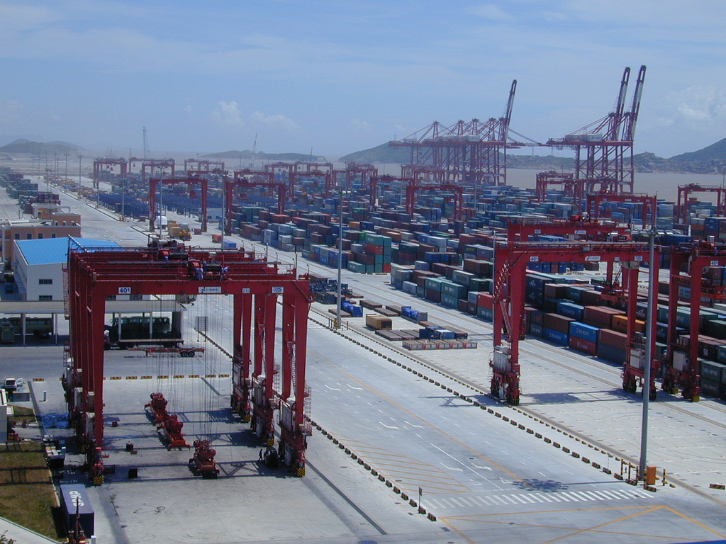

Yangshan deep-water port, Shanghai. Source: [Wikimedia Commons](https://commons.wikimedia.org/wiki/File:Port_of_Shanghai,_Yangshan_Deep-water_Harbour_Zone,_02.jpg), public domain.

## How we measure the shock?

The basic idea is simple:

**Which places were most exposed to competition from Chinese imports?**

Imagine two towns:

- **Town A** makes furniture, toys, and clothing — products China began exporting much more of.
- **Town B** is mostly hospitals, restaurants, and local services — things that are not imported from China.

**Town A gets a high import-exposure score.**  
**Town B gets a low one.**

## How we measure the shock?

The measure asks:

> How much did Chinese imports rise in the industries that workers in this local area depended on?

It then divides that increase by the number of workers in the area.

So **import exposure** is roughly:

**more Chinese imports in your local industries ÷ local workers**

A larger number means a bigger trade shock.

## How we measure the shock?

- The United States is divided into **722 commuting zones** — local labour markets where people live and work.
- Each zone gets its own import-exposure score.
- The study compares two periods: **1990–2000** and **2000–2007**.

**The key point:** the China shock was not equally large everywhere.  
It depended on **what your local economy produced before Chinese imports surged**.

## What the score actually is

That score has a unit: **dollars of Chinese imports per local worker**.

A zone scoring **$2,640** means:

> For every worker living there, an extra **$2,640** of Chinese goods were arriving each year, in the industries that zone worked in.

A zone of 100,000 workers scoring $2,640 faced about **$264 million a year** of new Chinese competition in its own industries.

## What the score is not

- It is **not a pay cut**. Nobody handed over $2,640
- It is **not** money the zone lost
- It is the **size of the wave** arriving, divided by the number of people standing in it

Dividing by workers is what makes a small town and a big city comparable. Detroit gets more imports than a mill town simply because Detroit is bigger — per worker, we can ask which one was hit harder.

## Where the China shock hit hardest

The shock was **not evenly spread across the United States**.

Some local economies depended heavily on industries that suddenly faced much more competition from Chinese imports.

Other places depended on industries that were barely affected.

## Where it landed

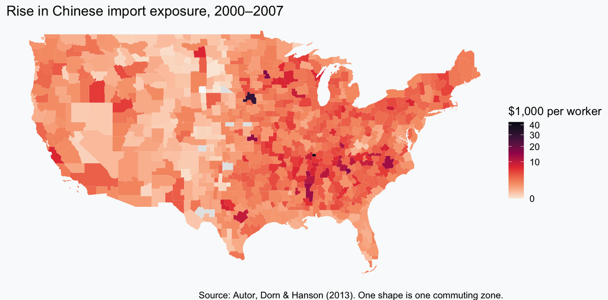

Figure 1

## Where it landed

So when you look at the map, read it like this:

- **Darker / higher-exposure areas** = places whose existing industries faced a larger increase in Chinese import competition.
- **Lighter / lower-exposure areas** = places whose local industries faced much less of that competition.

This does **not** mean that China “targeted” those places.

It means those places were more vulnerable because of **what they were already producing**.

## A few places took most of it

Extra Chinese imports arriving each year by 2007, per local worker:

- **The average zone:** $2,640
- **The hardest-hit zone:** $43,000 — more than **16 times** the average
- **The middle zone:** $1,900 — almost **two in three** zones came in *below* the average

The average sits above the typical place and far below the places that actually took the hit. It describes almost nobody.

## A few places took most of it

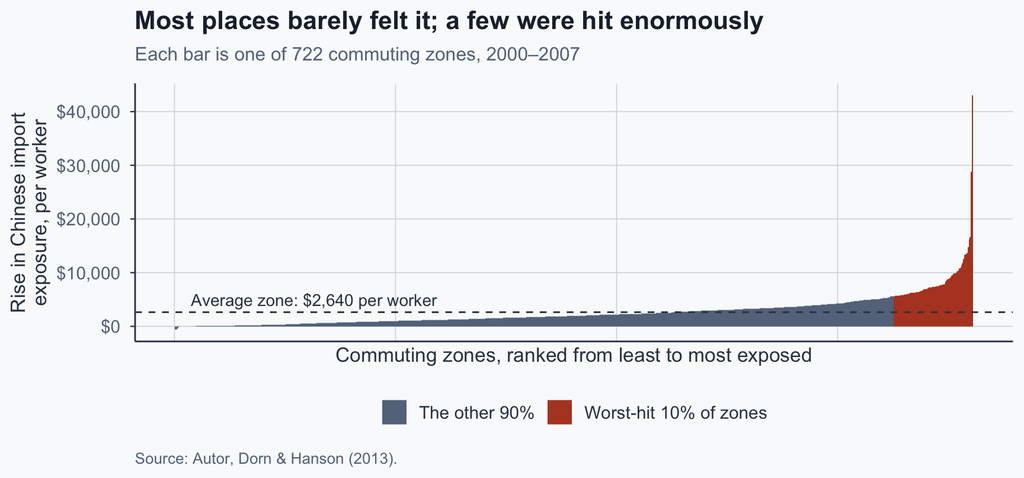

Figure 2

Those 72 red bars absorbed **a third** of the country’s entire shock.

## A few places took most of it

Where the red bars are:

- **Two-thirds** of the worst-hit zones are in the **South**
- Most of the rest are in the **Midwest**
- Only **2 of 72** are in the **West**

So this was not one shock the country shared. It was a small number of places taking a very large hit.

## So what?

- A national average hides where a shock actually lands
- The unit you choose decides what you can see
- Commuting zones show it; states would not

Which raises the real question: what happened to the people who lived there?

# II. What It Did to Those Places

## What decline looks like

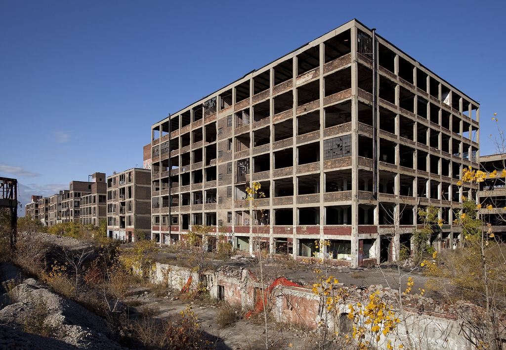

The abandoned Packard plant, Detroit. Source: [Wikimedia Commons](https://commons.wikimedia.org/wiki/File:Abandoned_Packard_Automobile_Factory_Detroit_200.jpg), CC BY-SA 3.0, Albert duce.

## More exposure, fewer factory jobs

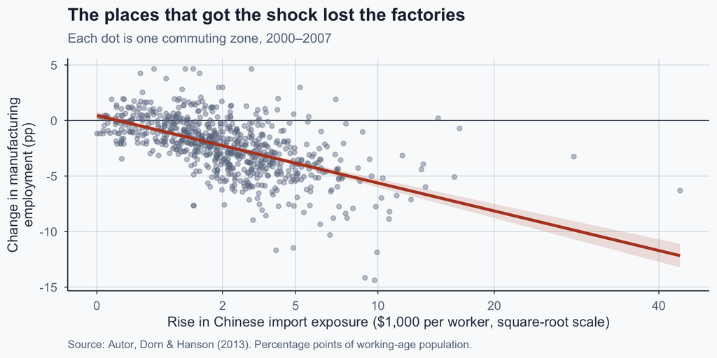

Figure 3

This plot is descriptive. The paper behind it uses a stronger research design to isolate Chinese competition — we are not learning that method today.

## The relationship got stronger

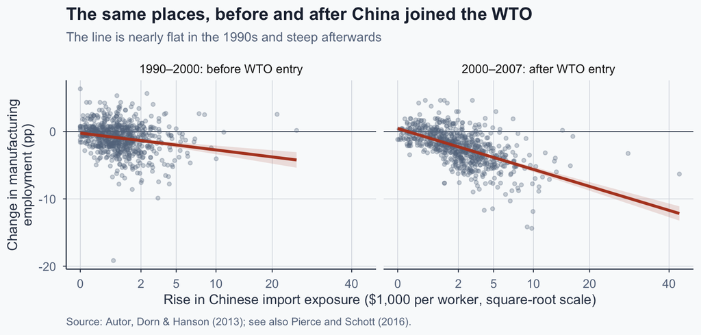

Figure 4

## Two ways to read the same loss

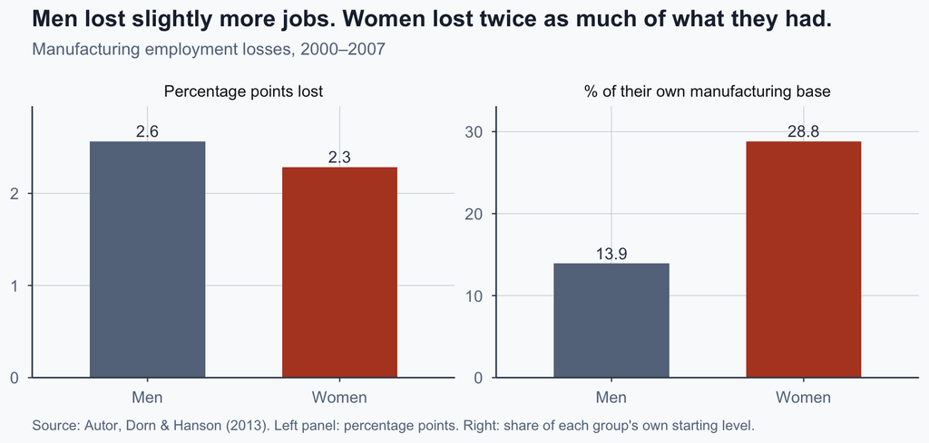

Figure 5

## Exercise 1 — Make a prediction

Your town’s only factory closes. You are forty, and you worked there.

**Rank these four, from most to least common:**

1. Move to another city
2. Find other work nearby
3. Become unemployed
4. Stop looking for work

**If your ranking is right, what should the data show?**

Example: if people move, hard-hit places should be *losing population*. Five minutes, in pairs.

## What happened in more-exposed places

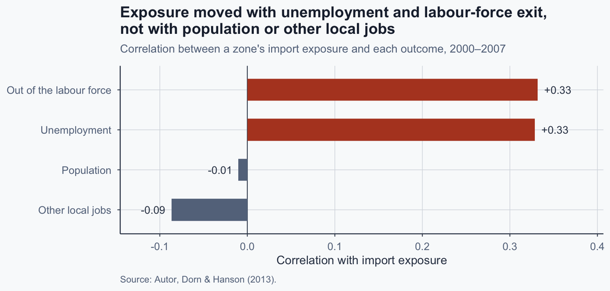

Figure 6

## The mechanism

```
%%{init: {"flowchart": {"useMaxWidth": true, "htmlLabels": true, "padding": 24,
                        "nodeSpacing": 22, "rankSpacing": 90,
                        "width": 1150, "height": 640},
          "themeVariables": {"fontSize": "21px", "fontFamily": "Arial, Helvetica, sans-serif"}} }%%
flowchart LR
  A["Imports<br/>arrive"] --> B["The plant<br/>closes"]
  B --> C["A new job<br/>nearby"]
  B --> D["Move to<br/>another city"]
  B --> E["Stop looking<br/>for work"]
  C --> F["Adjustment<br/>works"]
  D --> F
  E --> G["Adjustment<br/>fails"]
```

Figure 7

Author’s illustration, after Autor, Dorn and Hanson (2013). The data points to the bottom path.

## So what?

- Unemployment and labour-force exit rose **about equally** in hit places
- Neither moving away nor new local jobs absorbed the loss
- A place can lose its economy and keep its population

Autor, Dorn, Hanson and Majlesi (2020) followed those same places into politics. That is Lecture 2.

And the United States was not the only country in this story. Mexico was selling to the same customer.

# III. The Same Shock, Seen from Mexico

## Mexico was selling to the same customer

- NAFTA (1994) tied Mexican factories to the **US market**
- Maquiladoras assembled clothes, televisions and car parts for export
- After 2001, Chinese factories sold into **that same market**

So Mexico’s shock did not arrive as cheap imports at home. It arrived as **orders that went somewhere else**.

## 2003: the year China passed Mexico

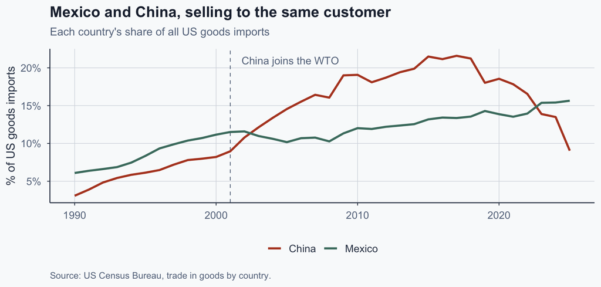

Figure 8

Mexico passed China again in 2023. Why is a question for another course.

## What happened inside Mexico

- Maquiladora **employment and growth fell** (Utar & Torres Ruiz 2013)
- The least skilled plants were hit hardest
- Exposed **regions** lost manufacturing employment (Méndez 2015)
- The loss was larger where they competed with China **in the US**

Wages barely moved. What changed was where people worked — and more of them moved between regions.

## Where manufacturing employment changed in Mexico

This is a **descriptive approximation** of the pattern discussed by Méndez (2015).

> **Where did manufacturing employment actually grow or shrink between 1998 and 2008?**

## Where manufacturing employment changed in Mexico

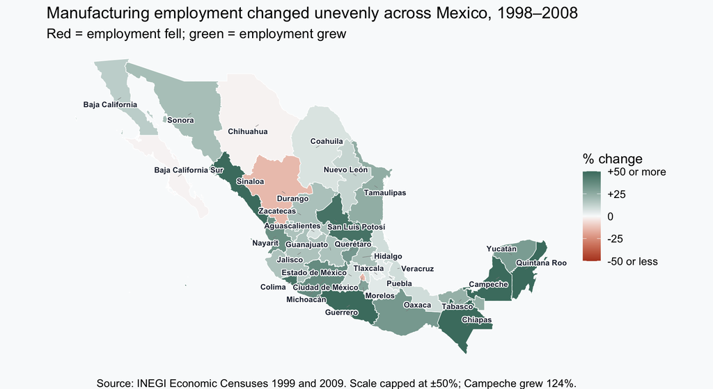

Figure 9

## Where manufacturing employment changed in Mexico

The map should be read carefully:

- **Red states** lost manufacturing jobs between 1998 and 2008.
- **Green states** gained manufacturing jobs.
- Only **four states** lost jobs; the country gained 12%.
- This does **not** by itself show that Chinese competition caused the change.

## Growth can slow without reversing

**Mexico gained manufacturing jobs overall. Exposed regions still lost out.**

A shock can hold growth below what it would otherwise have been, and employment still rises.

The map shows **what happened**. Méndez compares exposed regions with less exposed ones, which is closer to **what would have happened otherwise**. Those are different questions, and only the second one is about China.

## So what?

- The same measure travels: exposure follows what a place **produced**
- Mexico was hit through a **third market**, not at home
- And workers moved — remember that on **Wednesday**

Now: is the next shock going to look the same?

# IV. A Shock With a Different Shape

## AI is not a factory

|  | The China shock | AI |
| --- | --- | --- |
| **Arrives as** | a factory closing | a website opening |
| **Reaches** | towns that made those goods | anyone with a connection |
| **Exposure depends on** | what your town produced | what you ask it to do |

Town A never chose furniture imports. Everyone chooses what to type into a chatbot.

## The question changes

For the China shock we asked: **where did it land?**

Trade exposure followed the industries a place already had. AI is not tied to local industry in the same way.

> **What do people do with it once they have it?**

## The data

Most research on AI guesses which jobs a machine *could* do. This data records what people **actually asked it for**.

Millions of real conversations with Claude, stripped of anything identifying, each one labelled twice:

- **What for?** — work, study, or something personal
- **How?** — hand over the whole task, or work alongside it

**121 countries · May 2026 · one row is one country**

## Where the world’s AI use comes from

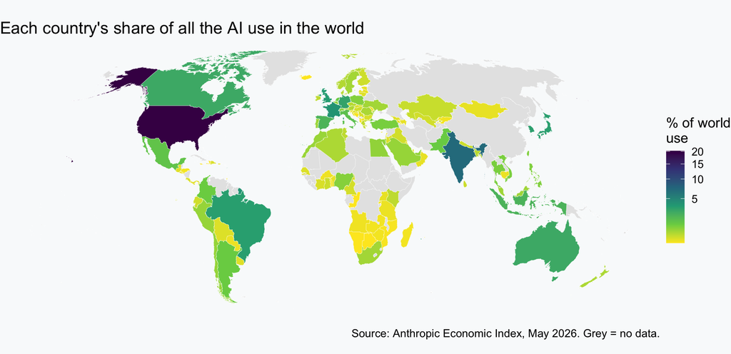

Figure 10

## Where it is used for schoolwork

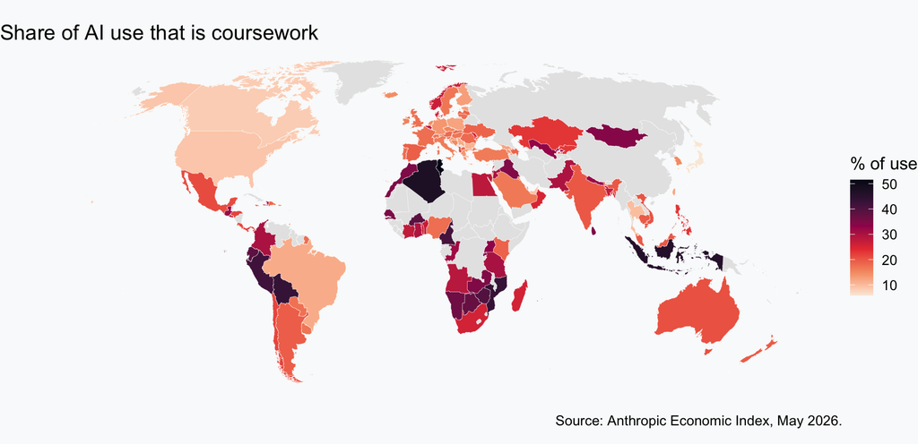

Figure 11

## Almost the opposite map

- The **United States** is 20% of world use; **9%** of it is coursework
- **Tunisia** is 0.3% of world use; **52%** of it is coursework
- **Mexico**: 1.3% of world use, coursework **21%**

The same tool, the same interface — and a completely different place in people’s lives.

## Exercise 2 — Can you say this?

**52% of Tunisian AI use is coursework** — the highest share in the world.

Which of these sentences does that number support?

1. Most Tunisians use AI for schoolwork.
2. Most Tunisian conversations with Claude are schoolwork.
3. Tunisians use AI for school more than Americans do.

**Mark each one yes or no. Rewrite the ones that fail.**

Five minutes, in pairs.

## The trap in that number

- **1. No** — it counts conversations, not people, and only Claude’s
- **2. Yes** — that is exactly what the 52% says
- **3. Careful** — a bigger *share* of a much smaller *amount*

Americans send **13 times** more coursework to Claude than Tunisians do.

## The trap in that number

- Claude users in Tunisia are young, urban, connected — not a cross-section
- The China shock counted **every worker in a place**
- Here the denominator is **whoever showed up**

Who is counted is the first question to ask of any dataset.

## So what?

- Trade exposure was fixed by a place’s **existing industries**
- AI exposure looks **more diffuse** — harder to pin to a map
- Use still varies by place, and *how* it is used varies more
- And we see **users**, not populations

So the hard questions move from *where it lands* to **who uses it, and how**.

Which leaves one question: are these two things even the same kind of event?

# V. Two Shocks, Two Shapes

## They are not the same shape

```
%%{init: {"flowchart": {"useMaxWidth": true, "htmlLabels": true, "padding": 24,
                        "nodeSpacing": 26, "rankSpacing": 95,
                        "width": 1150, "height": 640},
          "themeVariables": {"fontSize": "21px", "fontFamily": "Arial, Helvetica, sans-serif"}} }%%
flowchart LR
  A["Trade<br/>shock"] --> B["Follows local<br/>industry"]
  B --> C["You can<br/>map exposure"]
  D["AI"] --> E["Not tied to<br/>local industry"]
  E --> F["You must ask<br/>who uses it, and how"]
```

Figure 12

Author’s illustration. Different shapes need different evidence.

## What each dataset can show you

|  | China shock | AI |
| --- | --- | --- |
| One row is | A local labour market | A country |
| Who is counted | Every worker there | Only people who use the tool |
| Good for | Where it landed, what followed | What it is used for |
| Cannot show | Whether trade *alone* caused it | Anything about non-users |

## What we can say

- Import exposure and factory job loss move together, strongly
- The relationship is far stronger after 2001 than before
- Hard-hit places lost workers from the labour force, not to other cities

**Our plots are correlations. The paper is not.** Autor, Dorn and Hanson isolate the *Chinese* side of the shock by using the same industries’ exports to **other rich countries** — which is why economists read this as cause, not coincidence.

Autor, Dorn and Hanson (2016) review how well it held up.

## What we cannot say

- That trade **alone** caused it — automation was happening too
- That the same towns would have thrived otherwise
- That AI will repeat it: different shape, different data, no outcomes yet

Acemoglu and Restrepo (2020) find robots displacing the same kind of work in the same years. The honest position is that we know a great deal about the first shock and almost nothing yet about the second.

## Takeaways

1. Globalization’s gains were spread; its losses were **concentrated**
2. The unit you measure decides what you can see
3. Denominators decide headlines — ask **who is counted**
4. Hard-hit places did not empty out; they stopped working
5. AI is a different shape of shock, and it is early

> A national average is a sentence about nobody.

## References

Acemoglu, D., & Restrepo, P. (2020). Robots and jobs: Evidence from US labor markets. *Journal of Political Economy, 128*(6), 2188–2244.

Anthropic. (2026). *Anthropic Economic Index*, release of 26 June 2026. https://huggingface.co/datasets/Anthropic/EconomicIndex

Autor, D. H., Dorn, D., & Hanson, G. H. (2013). The China syndrome: Local labor market effects of import competition in the United States. *American Economic Review, 103*(6), 2121–2168.

## References (cont.)

Autor, D. H., Dorn, D., & Hanson, G. H. (2016). The China shock: Learning from labor-market adjustment to large changes in trade. *Annual Review of Economics, 8*, 205–240.

Autor, D. H., Dorn, D., Hanson, G. H., & Majlesi, K. (2020). Importing political polarization? The electoral consequences of rising trade exposure. *American Economic Review, 110*(10), 3139–3183.

Pierce, J. R., & Schott, P. K. (2016). The surprisingly swift decline of US manufacturing employment. *American Economic Review, 106*(7), 1632–1662.

## References (cont.)

Méndez, O. (2015). The effect of Chinese import competition on Mexican local labor markets. *The North American Journal of Economics and Finance, 34*, 364–380.

US Census Bureau. (2026). *Trade in goods by country*. https://www.census.gov/foreign-trade/balance/

Utar, H., & Torres Ruiz, L. B. (2013). International competition and industrial evolution: Evidence from the impact of Chinese competition on Mexican maquiladoras. *Journal of Development Economics, 105*, 267–287.